# 🤖 BTC Wheel Bot — Complete Strategy Explainer

## 5 · Short-put mechanics — walking through a real trade

Let's trace the full lifecycle of a real trade from the backtest.

```python
# Show all trades as a table first
display_cols = ['cycle_num','open_date','close_date','option_type','strike',
                'spot_at_open','dte','iv_rank','premium_usd','pnl_usd','annualised_yield']
print(trades[display_cols].to_string(index=False))
```

```
 cycle_num  open_date close_date option_type   strike  spot_at_open  dte  iv_rank  premium_usd  pnl_usd  annualised_yield
         1 2025-04-21 2025-04-28         put  85264.0       88518.0    7     36.1       261.30   -93.48         79.898483
         2 2025-04-28 2025-05-05        call  99300.0       94932.0    7     25.1       259.72   258.09         68.190045
         3 2025-10-10 2025-10-17         put 106602.0      110494.0    7     58.7       310.90   395.41         76.036164
         4 2025-10-17 2025-10-24        call 111769.0      106824.0    7     65.8       293.81   563.68         68.534624
         5 2025-10-24 2025-10-31         put 107128.0      111502.0    7     70.6       354.24   436.48         86.210355
         6 2025-10-31 2025-11-07        call 115675.0      110004.0    7     74.8       333.03  -157.28         75.060020
         7 2025-11-07 2025-11-14         put  98003.0      102288.0    7     45.5       350.50   422.96         93.242408
         8 2025-11-14 2025-11-21        call 100129.0       96226.0    7     61.5       234.89   129.17         61.160282
         9 2025-11-21 2025-11-28         put  81289.0       84494.0    7     64.7       258.41  -188.31         82.878592
        10 2025-11-28 2025-12-05        call  95033.0       90598.0    7     68.7       262.02   198.27         71.882775
        11 2025-12-05 2025-12-12         put  86006.0       89600.0    7     71.6       291.96    28.04         88.503294
        12 2025-12-12 2025-12-19        call  95012.0       90316.0    7     67.7       275.49     3.24         75.594850
        13 2025-12-19 2025-12-26         put  84771.0       88283.0    7     46.9       285.04   325.93         87.664414
        14 2025-12-26 2026-01-02        call  91110.0       87508.0    7     36.3       216.47   334.12         61.943608
        15 2026-01-02 2026-01-09         put  86880.0       89585.0    7     29.0       212.66  -107.37         63.816183
        16 2026-01-31 2026-02-07        call  81225.0       78278.0    7     91.1       178.51  -242.79         57.297762
        17 2026-02-07 2026-02-14         put  66400.0       69648.0    7     96.1       405.50    -5.91        106.144220
        18 2026-02-14 2026-02-21        call  75229.0       70760.0    7     97.8       383.39   144.80         88.578651
        19 2026-02-21 2026-02-28         put  64668.0       67966.0    7     99.2       414.93   -40.57        111.521596
        20 2026-02-28 2026-03-07        call  71748.0       67116.0    7     71.0       392.14   349.15         94.995912
        21 2026-03-07 2026-03-14         put  64450.0       67327.0    7     59.7       353.94    88.40         95.450959
        22 2026-03-14 2026-03-21        call  75001.0       71483.0    7     61.4       311.51   167.57         72.190244
        23 2026-03-21 2026-03-28         put  66173.0       68904.0    7     52.4       332.33   438.96         87.289558
        24 2026-03-28 2026-04-04        call  69704.0       66658.0    7     36.2       271.81   300.24         67.776837
        25 2026-04-04 2026-04-11         put  64728.0       66814.0    7     39.0       246.73  -238.06         66.252663
        26 2026-04-11 2026-04-18        call  74510.0       71690.0    7     34.3       255.23   116.69         59.537518
```

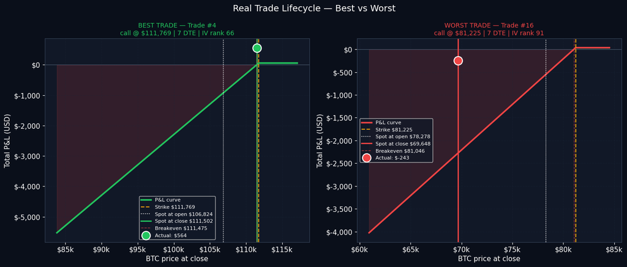

```
BEST TRADE (#4)
  Opened    : 2025-10-17 | Closed: 2025-10-24
  Type      : call @ $111,769
  BTC open  : $106,824 | BTC close: $111,502
  Premium   : $294 | P&L: $564
  Ann. yield: 69%

WORST TRADE (#16)
  Opened    : 2026-01-31 | Closed: 2026-02-07
  Type      : call @ $81,225
  BTC open  : $78,278 | BTC close: $69,648
  Premium   : $179 | P&L: $-243
  Ann. yield: 57%
```

```python
# ── Pick best and worst trade to analyse ────────────────────────────
t_best  = trades.loc[trades['pnl_usd'].idxmax()]
t_worst = trades.loc[trades['pnl_usd'].idxmin()]

fig, axes = plt.subplots(1, 2, figsize=(14, 6))
fig.suptitle('Real Trade Lifecycle — Best vs Worst', fontsize=14, color='white')

for ax, t, label, main_color in [
    (axes[0], t_best,  'BEST TRADE',  ACCENT),
    (axes[1], t_worst, 'WORST TRADE', DANGER),
]:
    strike   = t['strike']
    premium  = t['premium_usd'] / max(t['contracts'], 1)
    spot_o   = t['spot_at_open']
    spot_c   = t['spot_at_close']
    contrs   = t['contracts']

    lo = min(strike * 0.75, spot_c * 0.9)
    hi = max(spot_o * 1.08, spot_c * 1.05)
    prices_t = np.linspace(lo, hi, 400)
    pnl_t = np.where(prices_t >= strike,
                     premium, premium - (strike - prices_t)) * contrs

    ax.axhline(0, color='#475569', linewidth=0.8)
    ax.plot(prices_t, pnl_t, color=main_color, linewidth=2.5, label='P&L curve')
    ax.fill_between(prices_t, pnl_t, 0, where=np.array(pnl_t)>=0, alpha=0.15, color=ACCENT)
    ax.fill_between(prices_t, pnl_t, 0, where=np.array(pnl_t)<0,  alpha=0.15, color=DANGER)
    ax.axvline(strike,  color=ACCENT2, linewidth=1.5, linestyle='--', label=f'Strike ${strike:,.0f}')
    ax.axvline(spot_o,  color='white',  linewidth=1.2, linestyle=':',  label=f'Spot at open ${spot_o:,.0f}')
    ax.axvline(spot_c,  color=main_color, linewidth=2, linestyle='-', label=f'Spot at close ${spot_c:,.0f}')
    be = strike - premium
    ax.axvline(be, color=DANGER, linewidth=1, linestyle='--', alpha=0.7, label=f'Breakeven ${be:,.0f}')

    # Actual outcome dot
    actual = t['pnl_usd']
    ax.scatter([spot_c], [actual], s=180, color=main_color, zorder=10,
               edgecolors='white', linewidth=1.5, label=f'Actual: ${actual:,.0f}')

    ax.set_title(f'{label} — Trade #{int(t["cycle_num"])}\n'
                 f'{t["option_type"]} @ ${strike:,.0f} | {int(t["dte"])} DTE | IV rank {t["iv_rank"]:.0f}',
                 color=main_color, fontsize=10)
    ax.set_xlabel('BTC price at close')
    ax.set_ylabel('Total P&L (USD)')
    ax.yaxis.set_major_formatter(FuncFormatter(lambda x, _: f'${x:,.0f}'))
    ax.xaxis.set_major_formatter(FuncFormatter(lambda x, _: f'${x/1000:.0f}k'))
    ax.legend(fontsize=8)
    ax.grid(True, alpha=0.3)

plt.tight_layout()
plt.savefig(BASE / 'data' / 'chart_trade_lifecycle.png', dpi=150, bbox_inches='tight', facecolor=BG)
plt.show()

for label, t in [('BEST', t_best), ('WORST', t_worst)]:
    print(f'\n{label} TRADE (#{int(t["cycle_num"])})')
    print(f'  Opened    : {t["open_date"].date()} | Closed: {t["close_date"].date()}')
    print(f'  Type      : {t["option_type"]} @ ${t["strike"]:,.0f}')
    print(f'  BTC open  : ${t["spot_at_open"]:,.0f} | BTC close: ${t["spot_at_close"]:,.0f}')
    print(f'  Premium   : ${t["premium_usd"]:,.0f} | P&L: ${t["pnl_usd"]:,.0f}')
    print(f'  Ann. yield: {t["annualised_yield"]:.0f}%')
```

## 6 · Delta hedging with perpetual futures

A short put position is **directional** — it has negative delta, meaning it loses value when BTC crashes. The bot runs a **perpetual futures short** alongside the options position to partially neutralise this exposure.

### Why not fully hedge?

- Fully hedging kills the premium income advantage (the edge comes from being short volatility, not direction)
- Perp shorts pay/receive **funding rate** which can be significant
- The hedge is adjusted as delta changes (rebalancing), creating ongoing management costs
- The bot sizes the hedge based on the option's current delta and rebalances when it drifts

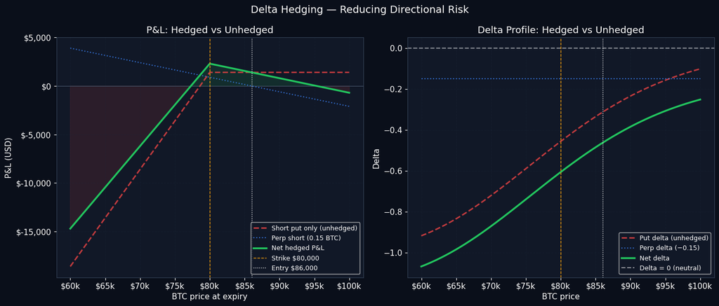

```
BTC −5%: Unhedged $   1,400  |  Hedged $   2,045  |  Hedge benefit $    +645
BTC −15%: Unhedged $  -5,500  |  Hedged $  -3,565  |  Hedge benefit $  +1,935
BTC −30%: Unhedged $ -18,400  |  Hedged $ -14,530  |  Hedge benefit $  +3,870
```

```python
# ── Visualise hedged vs unhedged P&L ───────────────────────────────
spot_e = 86_000
strike_h = 80_000
premium_h = 1_400
option_delta = -0.15   # put delta at entry
hedge_btc = abs(option_delta)   # BTC shorted in perps

prices_h = np.linspace(60_000, 100_000, 400)

# Unhedged: short put only
put_pnl = np.where(prices_h >= strike_h,
                   premium_h,
                   premium_h - (strike_h - prices_h))

# Perp P&L: short hedge_btc BTC from spot_e
perp_pnl = hedge_btc * (spot_e - prices_h)   # profits when price falls

# Combined
hedged_pnl = put_pnl + perp_pnl

fig, axes = plt.subplots(1, 2, figsize=(14, 6))
fig.suptitle('Delta Hedging — Reducing Directional Risk', fontsize=14, color='white')

# ── P&L comparison ──────────────────────────────────────────────────
ax = axes[0]
ax.axhline(0, color='#475569', linewidth=0.8)
ax.plot(prices_h, put_pnl,    color=DANGER,  linewidth=2,   linestyle='--', label='Short put only (unhedged)', alpha=0.8)
ax.plot(prices_h, perp_pnl,   color=ACCENT3, linewidth=1.5, linestyle=':',  label=f'Perp short ({hedge_btc:.2f} BTC)', alpha=0.8)
ax.plot(prices_h, hedged_pnl, color=ACCENT,  linewidth=2.5, label='Net hedged P&L')
ax.fill_between(prices_h, hedged_pnl, 0, where=np.array(hedged_pnl)>=0, alpha=0.12, color=ACCENT)
ax.fill_between(prices_h, hedged_pnl, 0, where=np.array(hedged_pnl)<0,  alpha=0.12, color=DANGER)
ax.axvline(strike_h, color=ACCENT2, linewidth=1, linestyle='--', label=f'Strike ${strike_h:,.0f}')
ax.axvline(spot_e,   color='white',  linewidth=1, linestyle=':',  label=f'Entry ${spot_e:,.0f}')
ax.set_title('P&L: Hedged vs Unhedged', color='white')
ax.set_xlabel('BTC price at expiry')
ax.set_ylabel('P&L (USD)')
ax.yaxis.set_major_formatter(FuncFormatter(lambda x, _: f'${x:,.0f}'))
ax.xaxis.set_major_formatter(FuncFormatter(lambda x, _: f'${x/1000:.0f}k'))
ax.legend(fontsize=9)
ax.grid(True, alpha=0.3)

# ── Net delta at each price ──────────────────────────────────────────
ax2 = axes[1]
T_h = 21/365
net_deltas = [bs_delta_put(p, strike_h, T_h, 0.80) + (-hedge_btc) * (-1) for p in prices_h]
# Note: short perp adds -1 delta per BTC (bearish). Short put adds negative delta.
# Net delta = put_delta + (-hedge_btc)  [perp short = negative delta]
net_deltas_correct = [bs_delta_put(p, strike_h, T_h, 0.80) - hedge_btc for p in prices_h]
put_deltas = [bs_delta_put(p, strike_h, T_h, 0.80) for p in prices_h]

ax2.plot(prices_h, put_deltas,         color=DANGER,  linewidth=2,   linestyle='--', label='Put delta (unhedged)', alpha=0.8)
ax2.plot(prices_h, [-hedge_btc]*len(prices_h), color=ACCENT3, linewidth=1.5, linestyle=':', label=f'Perp delta (−{hedge_btc:.2f})', alpha=0.8)
ax2.plot(prices_h, net_deltas_correct, color=ACCENT,  linewidth=2.5, label='Net delta')
ax2.axhline(0, color='white', linewidth=1.5, linestyle='--', alpha=0.5, label='Delta = 0 (neutral)')
ax2.axvline(strike_h, color=ACCENT2, linewidth=1, linestyle='--')
ax2.axvline(spot_e,   color='white',  linewidth=1, linestyle=':')
ax2.set_title('Delta Profile: Hedged vs Unhedged', color='white')
ax2.set_xlabel('BTC price')
ax2.set_ylabel('Delta')
ax2.xaxis.set_major_formatter(FuncFormatter(lambda x, _: f'${x/1000:.0f}k'))
ax2.legend(fontsize=9)
ax2.grid(True, alpha=0.3)

plt.tight_layout()
plt.savefig(BASE / 'data' / 'chart_delta_hedge.png', dpi=150, bbox_inches='tight', facecolor=BG)
plt.show()

# Show impact at specific scenarios
for scenario, price in [('BTC −5%', spot_e*0.95), ('BTC −15%', spot_e*0.85), ('BTC −30%', spot_e*0.70)]:
    put = float(np.interp(price, prices_h, put_pnl))
    hedged = float(np.interp(price, prices_h, hedged_pnl))
    improvement = hedged - put
    print(f'{scenario}: Unhedged ${put:>8,.0f}  |  Hedged ${hedged:>8,.0f}  |  Hedge benefit ${improvement:>+8,.0f}')
```